# Ejemplo de análisis (reproducible) de microarrays

Alex Sanchez

23/12/2015

# Introduccion y objetivos

Este documento presenta un ejercicio resuelto de análisis de microarrays. Su objetivo no es mostrar como realizar el mejor análisis de microarrays posible sino como hacerlo utilizando los conceptos y ejemplos proporcionados en las unidades dedicadas a este tema.

## Estructura del documento

Típicamente un trabajo científico o técnico se organiza en varias partes: *Introducción*, *Material y Métodos*, *Resultados* y *Discusión*. Dado que el objetivo de este estudio es demostrar la aplicación de los métodos de análisis explicados en la asignatura esta estructura se relajará. Después de la introducción se realizará una breve descripción del proceso general y los métodos utilizados en cada paso. A continuación se presentarán los resultados obtenidos en cada fase del análisis. Finalmente se presentará una breve discusión sobre las posibles limitaciones encontradas.

## Objetivos

El objetivo de este trabajo es realizar un análisis de datos de microarrays para encontrar genes diferencialmente expresados entre varios tipos de tumores de cancer de mama clasificados en tres grupos: apocrinos (APO), basales (BAS) y luminales (LUMI).

Esta clasificación se basa en la resistencia de los tumores a los receptores de estrógenos y de andrógenos.

- Los tumores clasificados como “APO” son negativos para los receptores de estrógenos (ER-) y positivos para los receptores de andrógenos (AR+).
- los clasificados como “LUMI” son (ER+) y (AR+) y
- los clasificados como “BAS” son (ER-) y (AR-).

Es conveniente destacar que, de hecho, el objetivo de la práctica difiere del objetivo del artículo en que se basa. Mientras que el artículo se busca *descubrir* los tres grupos con los que trabajamos en este ejercicio se pretende caracterizarlos a través de los gene que se expresan de forma distinta entre ellos. No deja de ser un problema del tipo ``el huevo y la gallina’’, es decir: *¿Puesto que se trata de grupos distintos encontramos genes que se expresan diferencialmente entre ellos o dado que hay genes que se expresan diferencialmente podemos deducir que son grupos distintos?*

# Materiales y métodos

## Etapas del analisis

El análisis se ha realizado siguiendo las pautas descritas en los capítulos 6 a 11 de los apuntes de la asignatura http://ueb.vhir.org/cursos/Microarrays y resumidos en la figura 1.

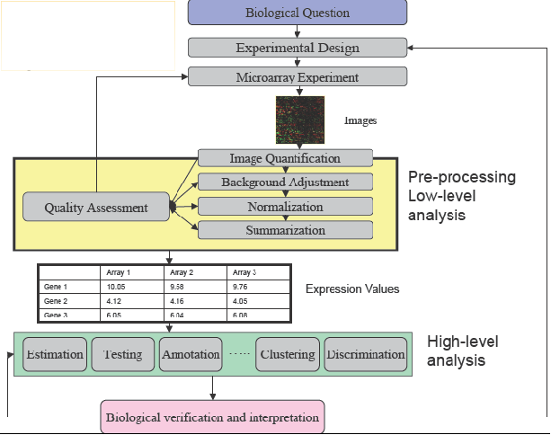

## Métodos de análisis

*Esta primera parte es ficticia en tanto que no hemos tendio acceso al proceso de elaboración de los microarrays, por lo que he escrito lo que suele ponerse en esta parte*

Antes de hibridar los microarrays se comprobó la calidad del cRNA de cada muestra. Sólo las que demostraron una calidad suficiente –presumiblemente un valor de ``Bio-analyser’’ igual o superior a 7– se sometieron a análisis posterior.

Los valores ``crudos’’ de expresión obtenidos directamente de los archivos CEL se preprocesa utilizando el método de RMA [@Irizarry:2003], un proceso de tres pasos que integra la corrección de fondo, la normalización y el resumen de los valores del grupo de sondas en un único valor de expresión *absoluta*. Dichos valores normalizados fueron la base para todos los análisis.

Antes de la selección de genes los valores normalizados se sometieron a un filtraje no específico para eliminar los genes de baja señal (los genes cuya media de la señal en cada grupo no supera un umbral mínimo) y los genes de baja variabilidad (los genes cuyo rango intercuartil entre todas las muestras no superó un umbral mínimo).

La seleccion de genes diferencialmente expresados entre condiciones experimentales se baso en la utilización de modelos lineales complementados con una moderación de la varianza mediante metodos bayesianos empiricos siguiendo la metodologia desarrollada por Smyth [@Smyth:2004]. Este método extiende el análisis de la varianza clásico utilizando métodos Bayesianos empíricos para combinar la información de cada gen individual con la de todos los genes restantes para obtener mejores estimaciones de error. Esto es de gran utilidad en análisis de microarrays, un contexto en el que el tamaño de las muestras es a menudo pequeño lo que puede dar lugar a estimaciones de los errores erráticos y, en consecuencia, p-valores que no son de fiar.

Los genes más relevantes de cada comparación se resaltaron utilizando *volcano-plots*, que organizan los genes a lo largo de dos dimensiones que podemos considerar de importancia biológica y estadística. El eje horizontal representa el cambio medio de expresión entre los dos grupos (en una escala logarítmica, por lo que la regulación hacia arriba y abajo aparecen simétrica), y el segundo (vertical) representa el *menos logaritmo del p-valor* por lo que los genes cuyo p-valor asociado sea inferior aparecen más arriba. El primer eje indica el impacto biológico del cambio, y el segundo indica la evidencia estadística, o la fiabilidad de dicho cambio.

Con el fin de hacer frente a la problemática derivada del hecho de que muchas pruebas (una por cada gen) se realizan simultáneamente, se realizo un ajuste de p–valores para obtener control sobre la tasa de falsos positivos usando el método de Benjamini y Hochberg [@BenjaminiHochberg:1995].

Los genes seleccionados como diferencialmente expresados se agruparon para buscar patrones comunes de expresión entre condiciones experimentales. Para ello se utilizaron mapas de colores o *Heatmaps* que realizan una agrupación jerárquica de los genes y/o las muestras y la representan mediante una gama de colores apropiada, de forma que valores altos o bajos se corresponden a colores distintos de la gama escogida.

Las listas de genes diferencialmente expresados se anotaron en diversas bases de datos (Entrez, Unigene, Gene Ontology, KEGG, …) utilizando los paquetes de anotación para microarrays de affymetrix disponibles en el proyecto Bioconductor http://bioconductor.org.

Para contribuir a la interpretación biológica de los resultados se realizó un análisis de enriquecimiento [@Gentleman:2004] que busca establecer si las categorias funcionales de los genes seleccionados aparecen entre estos genes con mayor (o menor) frecuencia que entre todos los del genoma. De ser así se indica que la lista de genes se encuentra “enriquecida” en estas funcionalidades, o lo que es lo mismo que los procesos afectados por las diferencias son éstos.

### Herramientas y procedimientos bioinformáticos de análisis

Los análisis estadísticos se realizaron utilizando el lenguaje estadístico R y las librerías desarrolladas para el análisis de microarray en el proyecto de Bioconductor. Para más detalle sobre los métodos descritos en esta sección puede consultarse [@Gentleman:2005].

El código siguiente se utilizó para instalar los paquetes de Bioconductor necesarios para el análisis.

```r
installifnot <- function (pckgName){
if(!(require(pckgName, character.only=TRUE))){
  source("http://Bioconductor.org/biocLite.R")
  biocLite(pckgName)
  }
}
installifnot("Biobase")
installifnot("hgu133a.db")
installifnot("affy")
installifnot("limma")
installifnot("annotate")
installifnot("hwriter")
installifnot("gplots")
installifnot("GOstats")
```

# Obtención y lectura de los datos

## Los datos para el análisis

Los datos en que se basa el estudio se han obtenido a partir de tumores de mama (“advanced/inflammatory breast tumours”) y fueron tomados antes del tratamiento de pacientes enrolados en un estudio clı́nico (EORTC 10994). Los microarrays se prepararon a partir de RNA total extraı́do de secciones de 25 mm de biopsias y amplificados mediante el procedimiento “Eberwine T7 procedure” siguiendo el protocolo indicado por Affymetrix para pequeñas muestras. Los datos de los microarrays se encuentran en Gene Expression Omnibus (GEO) con el número de serie GSE1561. Puede accederse a ellos en el siguiente enlace http://www.ncbi.nlm.nih.gov/geo/query/acc.cgi?acc=GSE1561. El artı́culo de Farmer ([4]) et alt.(http://www.ncbi.nlm.nih.gov/pubmed/15897907) describe el estudio.

## Localización de los datos

Como es habitual en este curso supondremos que trabajamos en un directorio escogido por nosotros y cuya localización se asigna a la variable workingDir. Asumiremos que los datos se encuentran en un subdirectorio del anterior, denominado “data” que se almacenará en la variable dataDir y que los resultados se almacenarán en un directorio “results” cuyo nombre completo se almacenará en la variable resultsDir.

```r
workingDir <-getwd()
dataDir <-file.path(workingDir, "data")
resultsDir <- file.path(workingDir,"results")
celfilesDir <- file.path(workingDir,"celfiles")
setwd(workingDir)
```

# Selección de genes diferencialmente expresados

```r
load (file=file.path(resultsDir, "datos.normalizados.Rda"))
```

Como en las etapas anteriores la selección de genes diferencialmente expresados (GDE) puede basarse en distintas aproximaciones, desde la t de Student al programa SAM pasando por multitud de variantes. En este ejemplo, dado que se realizaran tres comparaciones que luego deseamos comparar entre ellas, se aplicará la aproximación presentada por Smyth et al. (2004) basado en la utilización del modelo lineal general combinada con un método para obtener una estimación mejorada de la varianza.

## Análisis basado en modelos lineales

### Matrices de diseño y de contrastes

El primer paso para el análisis basado en modelos lineales es crear la matriz de diseño. Básicamente se trata de una tabla que describe la asignación de cada muestra a un grupo. Tiene tantas filas como muestras y tantas columnas como grupos (si solo se considera un factor)Cada fila contiene un uno en la columna del grupo al que pertenece la muestra y un cero en las restantes. La matriz de contrastes esse utiliza para describir las comparaciones entre grupos. Consta de tantas columnas como comparaciones y tantas filas como grupos (es decir como columnas de la matriz de diseño). Una comparación entre grupos –lamada “contraste”– se representa con un “1” y un “-1” en las filas de los grupos a comparar y ceros en las restantes. Si varios grupos intervinieran en la comparación se tendrı́a tantos coeeficientes como grupos con la única restricción de que su suma serı́a cero. La matriz de diseño puede definirse manualmente o a partir de un factor creado especı́ficamente para ello. Manualmente, seria:

```r
design<-matrix(
            c(1,1,1,1,1,0,0,0,0,0,0,0,0,0,0,
              0,0,0,0,0,1,1,1,1,1,0,0,0,0,0,
              0,0,0,0,0,0,0,0,0,0,1,1,1,1,1),
            nrow=15,byrow=F)
colnames(design)<-c("A", "B", "L")
print(design)
```

```
##       A B L
##  [1,] 1 0 0
##  [2,] 1 0 0
##  [3,] 1 0 0
##  [4,] 1 0 0
##  [5,] 1 0 0
##  [6,] 0 1 0
##  [7,] 0 1 0
##  [8,] 0 1 0
##  [9,] 0 1 0
## [10,] 0 1 0
## [11,] 0 0 1
## [12,] 0 0 1
## [13,] 0 0 1
## [14,] 0 0 1
## [15,] 0 0 1
```

Las comparaciones que nos interesan son las diferencias, dos a dos entre cada tipo de tumor lo que puede hacerse con los contrastes siguientes:

```r
require(limma)
cont.matrix <- makeContrasts (
      AvsB = B-A,
      AvsL = L-A,
      BvsL = L-B,
      levels=design)
print(cont.matrix)
```

```
##       Contrasts
## Levels AvsB AvsL BvsL
##      A   -1   -1    0
##      B    1    0   -1
##      L    0    1    1
```

### Estimación del modelo y selección de genes

Una vez definida la matriz de diseño y los contrastes podemos pasar a estimar el modelo, estimar los contrastes y realizar las pruebas de significación que nos indiquen, para cada gen y cada comparación, si puede considerarse diferencialmente expresado. El método implementado en limma amplı́a el análisis tradicional utilizando modelos de Bayes empı́ricos para combinar la información de toda la matriz de datos y de cada gen individual y obtener estimaciones de error mejoradas. El análisis proporciona los estadı́sticos de test habituales como Fold-change t-moderados o p-valores ajustados que se utilizan para ordenar los genes de mas a menos diferencialmente expresados. A fin de controlar el porcentaje de falsos positivos que puedan resultar del alto numero de contrastes realizados simultaneamente los p–valores se ajustan de forma que tengamos control sobre la tasa de falsos positivos utilizando el metodo de Benjamini y Hochberg ([1]).

```r
require(limma)
fit<-lmFit(eset_rma, design)
fit.main<-contrasts.fit(fit, cont.matrix)
fit.main<-eBayes(fit.main)
```

La funcion topTable genera para cada contraste una lista de genes ordenados de mas a menos diferencialmente expresados.

```r
topTab_AvsB <- topTable (fit.main, number=nrow(fit.main), coef="AvsB", adjust="fdr"); head(topTab_AvsB)
```

```
##                 logFC   AveExpr         t      P.Value    adj.P.Val
## 204667_at   -3.038344  8.651157 -17.65663 6.381142e-11 1.421910e-06
## 215729_s_at  3.452290  6.137595  13.67095 1.866493e-09 2.079553e-05
## 202579_x_at  1.293975 10.226164  12.26570 7.572654e-09 5.243573e-05
## 209787_s_at  2.023113  9.871298  12.05888 9.412689e-09 5.243573e-05
## 214243_s_at -5.015130  9.278980 -11.47539 1.768910e-08 6.752975e-05
## 220192_x_at -3.016315  9.521883 -11.45045 1.818330e-08 6.752975e-05
##                     B
## 204667_at   13.610350
## 215729_s_at 11.214963
## 202579_x_at 10.115252
## 209787_s_at  9.939472
## 214243_s_at  9.422507
## 220192_x_at  9.399692
```

```r
topTab_AvsL <- topTable (fit.main, number=nrow(fit.main), coef="AvsL", adjust="fdr"); head(topTab_AvsL)
```

```
##                 logFC  AveExpr         t      P.Value   adj.P.Val        B
## 205009_at    4.735050 8.692478 10.065389 9.116376e-08 0.001347635 7.417049
## 205862_at    3.958563 6.082835  9.667149 1.496627e-07 0.001347635 7.041503
## 205225_at    3.964939 9.300546  9.515779 1.814345e-07 0.001347635 6.893704
## 209443_at    2.198392 7.586226  9.275063 2.476026e-07 0.001371264 6.652732
## 209787_s_at  1.528306 9.871298  9.109555 3.076929e-07 0.001371264 6.482718
## 214243_s_at -3.857600 9.278980 -8.826786 4.490296e-07 0.001667621 6.183853
```

```r
topTab_BvsL  <- topTable (fit.main, number=nrow(fit.main) , coef="BvsL", adjust="fdr"); head(topTab_BvsL)
```

```
##                 logFC   AveExpr          t      P.Value    adj.P.Val
## 204667_at    2.961042  8.651157  17.207411 8.999579e-11 2.005376e-06
## 215729_s_at -3.744599  6.137595 -14.828480 6.449576e-10 7.185795e-06
## 205009_at    5.729322  8.692478  12.178933 8.293077e-09 6.159821e-05
## 209604_s_at  3.677596 10.746404  10.371789 6.289599e-08 3.503778e-04
## 209603_at    3.734793  8.584254   9.817179 1.239430e-07 5.523646e-04
## 209443_at    2.263556  7.586226   9.549995 1.736737e-07 6.250299e-04
##                     B
## 204667_at   12.241299
## 215729_s_at 11.095977
## 205009_at    9.399629
## 209604_s_at  7.898532
## 209603_at    7.368304
## 209443_at    7.099826
```

Un volcano-plot es una figuras que permite visualizar si hay muchos o pocos genes con un gran fold-change y significativamente expresados o si este número es bajo. Estos gráficos representa en abscisas los cambios de expresión en escala logarı́tmica y en ordenadas el “menos logaritmo” del p-valor o alternativamente el estadı́stico B (“log-odds”).

```r
annotation(eset_rma)
```

```
## [1] "hgu133a"
```

```r
probeNames <-rownames(fit.main)
Symbols <- getSYMBOL(probeNames, annotation(eset_rma))
myNames <- paste(probeNames, Symbols, sep=".")
head(myNames)
```

```
## [1] "1007_s_at.NA"     "1053_at.RFC2"     "117_at.HSPA6"
## [4] "121_at.PAX8"      "1255_g_at.GUCA1A" "1294_at.NA"
```

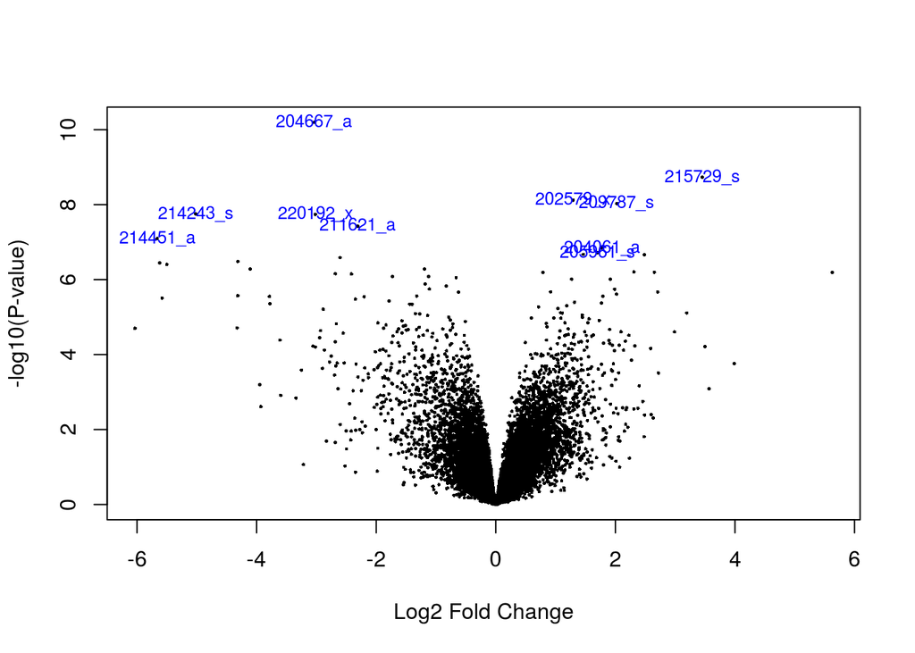

```r
volcanoplot(fit.main, coef="AvsB", highlight=10, names=myNames)
```

# Post-procesado de las listas de genes obtenidas

Una vez obtenidas las listas de genes diferencialmente expresados pueden llevarse a cabo todo tipo de análisis sobre ellas, generalmente encaminados a facilitar la interpretación de los resultados. Entre estas exploraciones –que podemos llamar genericamente“post-procesado de las listas” se encuentra La anotación de las listas de genes en diversas bases de datos. La comparación entre las listas para determinar que genes cambian simultaneamente -o no- en varias comparaciones (o cuales cambian en una comparación pero no en otra). La visualización de todos los genes seleccionados en varias comparaciones para, de forma similar a lo anterior, detectar grupos de genes con patrones de cambio similares –o distintos– entre distintas comparaciones. EL análisis de significación biológica de las listas mediante análisis de enriquecimiento o mediante “gene set analysis” para detectar si las listas se encuentran enriquecidas en genes asociados a funciones o procesos biológicos determinados.

**Esta parte del análisis no se presenta en este documento, aunque puede verse la misma en el documento “EjemploAnalisisMicroarrays.Rnw”**